# K Means Clustering Using R

## Difficult Clusters

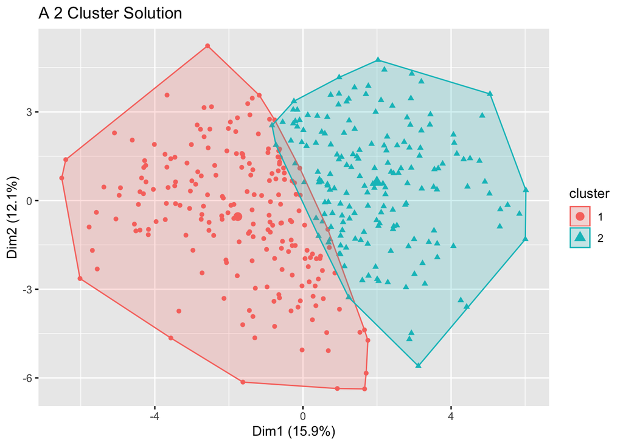

```r
fviz_cluster(fit1, geom = "point", data = MyData) + ggtitle("A 2 Cluster Solution")
```

# Conclusion

##### During this assingment, we have used a k-means clustering method to classify data. As we are dealing with distances, it is important to make sure that the data is numberic. Scaling the data also helps to evaluate k distances and sum of squares. Furthermore, making sure we get rid of NA or NULL values from the dataset is important as we are dealing with distances. It is also important to find the optimal k values. Depending on the K values, we may have completely different classification of data observations. Therefore, finding a working optimal k value is very key.

# References

1. https://towardsdatascience.com/10-tips-for-choosing-the-optimal-number-of-clusters-277e93d72d92  
   https://uc-r.github.io/kmeans_clustering  
   https://www.r-bloggers.com/10-tips-for-choosing-the-optimal-number-of-clusters/